# Foundations of Machine Learning Frameworks Lab-9

Name: Devanshi Joshi  
Id: 8868052

1. Using Keras Datasets, obtain the fMNIST data set. Explore and describe it as you would do with any new dataset that you start working with (2 points).

```python
# Importing the libraries
from tensorflow.keras.datasets import fashion_mnist
from tensorflow import keras
from sklearn.metrics import confusion_matrix
import tensorflow as tf
import matplotlib.pyplot as plt
import numpy as np
import pandas as pd
from tensorflow.keras.utils import to_categorical
from tensorflow.keras.models import Sequential
from tensorflow.keras.layers import Dense
```

Dataset info link: [Link](https://github.com/zalandoresearch/fashion-mnist)  
Wikipedia link for the information on the fMNIST data set [Fashion MNIST](https://en.wikipedia.org/wiki/Fashion_MNIST)  
According to the information found from the above link:

- Each training and testing example has been assigned one of the following labels:

| Label | Description |
| --- | --- |
| 0 | T-shirt/top |
| 1 | Trouser |
| 2 | Pullover |
| 3 | Dress |
| 4 | Coat |
| 5 | Sandal |
| 6 | Shirt |
| 7 | Sneaker |
| 8 | Bag |
| 9 | Ankle boot |

#### Loading the dataset and reviewing the shape of the trainings and testing data

```python
(x_train, y_train), (x_test, y_test) = fashion_mnist.load_data()
```

```python
# Display basic information about the dataset
print(f"Training Data Shape: {x_train.shape}")
print(f"Training Labels Shape: {y_train.shape}")
print(f"Test Data Shape: {x_test.shape}")
print(f"Test Labels Shape: {y_test.shape}")
```

```
Training Data Shape: (60000, 28, 28)
Training Labels Shape: (60000,)
Test Data Shape: (10000, 28, 28)
Test Labels Shape: (10000,)
```

There are 60000 training images which have 28x28 pixels for each image.  
There are 10000 testing images which have 28x28 pixels for each image.

```python
# Defining the class names based on the info gathered
class_names = ['T-shirt/top', 'Trouser', 'Pullover', 'Dress', 'Coat', 'Sandal', 'Shirt', 'Sneaker', 'Bag', 'Ankle boot']
```

#### Visualizing the first few images in the dataset

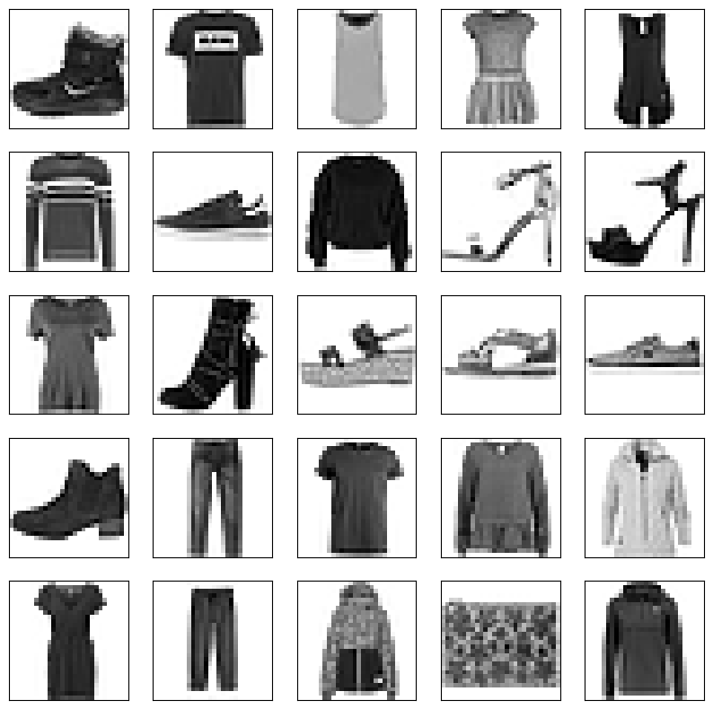

```python
plt.figure(figsize=(10, 10))
for i in range(25):
    plt.subplot(5, 5, i + 1)
    plt.xticks([])
    plt.yticks([])
    plt.grid(False)
    plt.imshow(x_train[i], cmap=plt.cm.binary)
plt.show()
```

```python
# Print labels for the first 25 images
print("Labels for the first 25 images:")
for i in range(25):
    print(f'Image {i+1} label: {class_names[y_train[i]]}')
```

```
Labels for the first 25 images:
Image 1 label: Ankle boot
Image 2 label: T-shirt/top
Image 3 label: T-shirt/top
Image 4 label: Dress
Image 5 label: T-shirt/top
Image 6 label: Pullover
Image 7 label: Sneaker
Image 8 label: Pullover
Image 9 label: Sandal
Image 10 label: Sandal
Image 11 label: T-shirt/top
Image 12 label: Ankle boot
Image 13 label: Sandal
Image 14 label: Sandal
Image 15 label: Sneaker
Image 16 label: Ankle boot
Image 17 label: Trouser
Image 18 label: T-shirt/top
Image 19 label: Shirt
Image 20 label: Coat
Image 21 label: Dress
Image 22 label: Trouser
Image 23 label: Coat
Image 24 label: Bag
Image 25 label: Coat
```

2. Train a dense neural network using Keras, try out at least three hyperparameters configurations (2 points)

#### Reshaping the images:

- Input Shape for Dense Layers: Fashion MNIST pictures are 2D (28x28 pixels), while denser layers in a neural network require each input to be a vector (1D). Each 2D image is flattened into a 1D array so that it may be used with the thick layers.
- Consistency: This stage makes sure that every image has the same shape and that the neural network can analyse them all equally.

```python
# Flatten the images
x_train = x_train.reshape((60000, 28*28))
x_test = x_test.reshape((10000, 28*28))
```

#### Normalizing the values:

- Scaling: An image's pixel values span from 0 to 255. Scaled to a narrow range input data tends to perform better for neural networks. The pixel values are scaled to the [0, 1] range by dividing by 255.
- Convergence: By aiding in the loss function's convergence, normalisation helps to accelerate training. Similar-scale inputs cause the gradients to oscillate less during training, resulting in a faster and more stable convergence.

```python
# Normalize the pixel values
x_train = x_train.astype("float32") / 255.0
x_test = x_test.astype("float32") / 255.0
```

#### One-Hot Encoding the Labels:

- Multi-Class Classification: With ten classes, the Fashion MNIST dataset presents a multi-class classification challenge. Categorical integer labels are transformed into a binary matrix representation using one-hot encoding.
- Model Compatibility: The majority of neural network architectures require the labels to be in a format that is appropriate for the loss function and the output layer.

```python
# One-hot encode the labels
y_train = to_categorical(y_train, 10)
y_test = to_categorical(y_test, 10)
```

```python
def create_model():
    model = Sequential([
        Dense(128, activation='relu'),
        Dense(10, activation='softmax')
    ])
    return model
```

#### The choice of loss function: categorical_crossentropy

I have selected the loss function as categorical_crossentropy due to the presence of multiclass classification. Due to which we have to one-hot encode the labels of the dataset.  
For sparse categorical cross-entropy integer encode labels are required.

```python
model = create_model()
model.compile(optimizer="rmsprop",  loss="categorical_crossentropy", metrics=["accuracy"])
model.fit(x_train, y_train, epochs=10, batch_size=100)
```

```
<keras.callbacks.History at 0x1d144ef5e10>
```

#### Configuration 1: Different Number of Neurons

```python
modelNeurons = create_model()
modelNeurons.layers[0].units = 500
modelNeurons.compile(optimizer='rmsprop', loss='categorical_crossentropy', metrics=['accuracy'])
modelNeurons.fit(x_train, y_train, epochs=10, batch_size=100)
```

```
<keras.callbacks.History at 0x1d146e3b710>
```

#### Configuration 2: Different Activation Function

```python
def create_model():
    model = Sequential([
        Dense(128, activation='sigmoid'),
        Dense(10, activation='softmax')
    ])
    return model

modelActivate = create_model()
modelActivate.compile(optimizer='rmsprop', loss='categorical_crossentropy', metrics=['accuracy'])
modelActivate.fit(x_train, y_train, epochs=10, batch_size=100)
```

```
<keras.callbacks.History at 0x1d14868a910>
```

#### Configuration 3: Different Optimizer

optizimer = [Adam](https://keras.io/api/optimizers/adam/)

```python
modelOptimize = create_model()
modelOptimize.compile(optimizer='adam', loss='categorical_crossentropy', metrics=['accuracy'])
modelOptimize.fit(x_train, y_train, epochs=10, batch_size=100)
```

```
<keras.callbacks.History at 0x1d1486ae1d0>
```

3. Evaluate its accuracy for each of the configurations. Choose the best configuration, and: Report its accuracy, confusion metric, and specific examples of incorrect classification, and drew some conclusions from this exploration (2 points)

```python
accuracyResults = {
    "Configuration": [
        "Default",
        "Neurons change",
        "Activation change",
        "Optimizer change"
    ],
    "Activation Function": [
        "ReLU",
        "ReLU",
        "Sigmoid",
        "ReLU"
    ],
    "Optimizer": [
        "RMSprop",
        "RMSprop",
        "RMSprop",
        "Adam"
    ],
    "Final Accuracy (%)": [90.61, 91.37, 89.09, 89.64],
    "Loss": [0.2560, 0.2347, 0.2989, 0.2877]
}

Accuracy = pd.DataFrame(accuracyResults)
Accuracy
```

|  | Configuration | Activation Function | Optimizer | Final Accuracy (%) | Loss |
| --- | --- | --- | --- | --- | --- |
| 0 | Default | ReLU | RMSprop | 90.61 | 0.2560 |
| 1 | Neurons change | ReLU | RMSprop | 91.37 | 0.2347 |
| 2 | Activation change | Sigmoid | RMSprop | 89.09 | 0.2989 |
| 3 | Optimizer change | ReLU | Adam | 89.64 | 0.2877 |

- Highest Accuracy: The layer configuration with 500 neurons (91.37%) had the highest accuracy, suggesting that expanding the model's capacity can aid in the discovery of more intricate patterns in the data.
- ReLU vs. Sigmoid Activation: The default configuration that used ReLU activation performed better than the one that used sigmoid activation. This is consistent with the widely held belief that ReLU is more effective for deeper networks.
- Comparing Optimizers: The RMSprop optimizer produced superior results than the Adam optimizer, both in its default setup and with more neurons. Even while Adam is renowned for working well in a variety of situations, RMSprop appears to have the advantage in this one.

```python
# Evaluate each model on the test data
model_evaluations = {
    'default': model.evaluate(x_test, y_test, verbose=0),
    'increased_neurons': modelNeurons.evaluate(x_test, y_test, verbose=0),
    'sigmoid_activation': modelActivate.evaluate(x_test, y_test, verbose=0),
    'adam_optimizer': modelOptimize.evaluate(x_test, y_test, verbose=0)
}

# Print the evaluations
for config, eval in model_evaluations.items():
    print(f"{config} - Test Loss: {eval[0]}, Test Accuracy: {eval[1]}")
```

```
default - Test Loss: 0.34220975637435913, Test Accuracy: 0.879800021648407
increased_neurons - Test Loss: 0.33756932616233826, Test Accuracy: 0.8855000138282776
sigmoid_activation - Test Loss: 0.3528370261192322, Test Accuracy: 0.8740000128746033
adam_optimizer - Test Loss: 0.34220975637435913, Test Accuracy: 0.879800021648407
```

#### Retraining the models to save the history of the runs for epochs and the changes and further plot the graphs for accuracy and loss comparing the performance on the training and testing sets

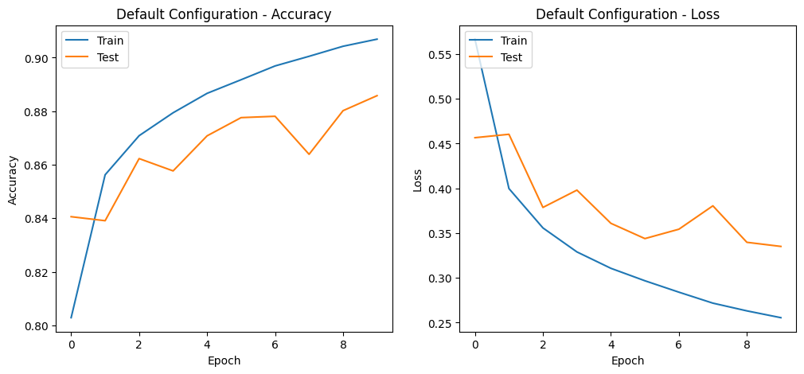

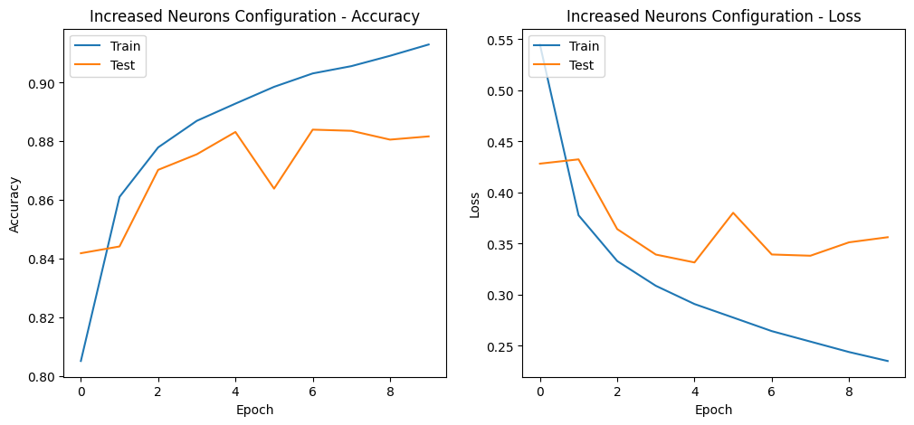

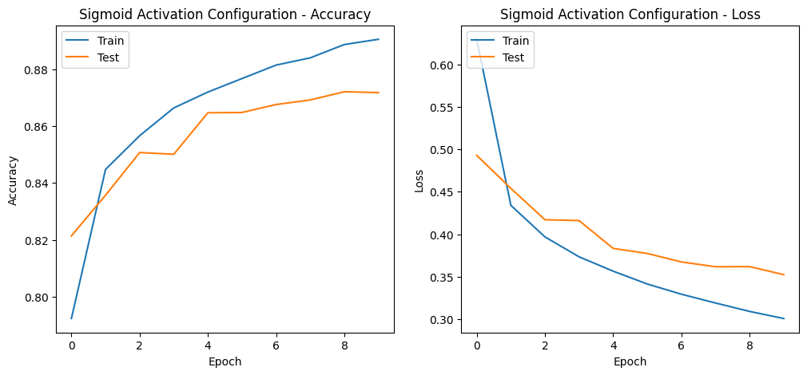

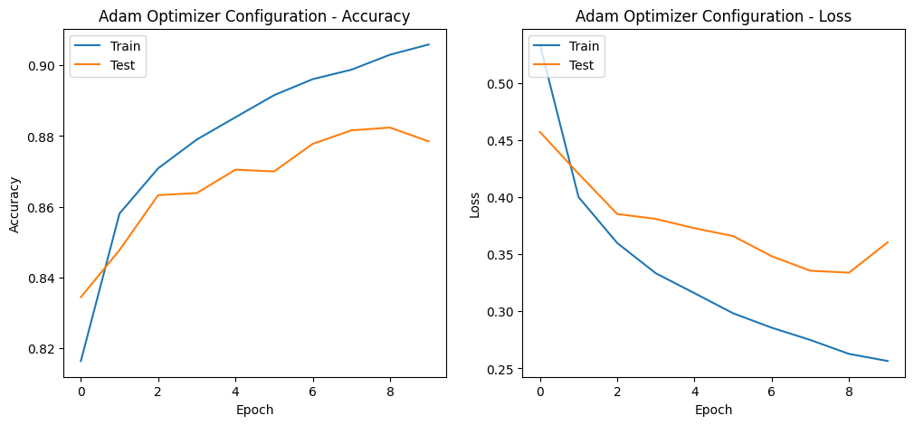

```python
def create_model(activation='relu', neurons=128):
    model = Sequential([
        Dense(neurons, activation=activation),
        Dense(10, activation='softmax')
    ])
    return model

def train_model(activation='relu', optimizer='rmsprop', neurons=128, epochs=10, batch_size=100):
    model = create_model(activation=activation, neurons=neurons)
    model.compile(optimizer=optimizer, loss='categorical_crossentropy', metrics=['accuracy'])
    history = model.fit(x_train, y_train, epochs=epochs, batch_size=batch_size, validation_data=(x_test, y_test), verbose=0)
    return model, history

model_default, history_default = train_model()
model_neurons, history_neurons = train_model(neurons=500)
model_sigmoid, history_sigmoid = train_model(activation='sigmoid')
model_adam, history_adam = train_model(optimizer='adam')

def plot_model_performance(history, title):
    plt.figure(figsize=(12, 5))

    plt.subplot(1, 2, 1)
    plt.plot(history.history['accuracy'])
    plt.plot(history.history['val_accuracy'])
    plt.title(f'{title} - Accuracy')
    plt.xlabel('Epoch')
    plt.ylabel('Accuracy')
    plt.legend(['Train', 'Test'], loc='upper left')

    plt.subplot(1, 2, 2)
    plt.plot(history.history['loss'])
    plt.plot(history.history['val_loss'])
    plt.title(f'{title} - Loss')
    plt.xlabel('Epoch')
    plt.ylabel('Loss')
    plt.legend(['Train', 'Test'], loc='upper left')

    plt.show()

plot_model_performance(history_default, 'Default Configuration')
plot_model_performance(history_neurons, 'Increased Neurons Configuration')
plot_model_performance(history_sigmoid, 'Sigmoid Activation Configuration')
plot_model_performance(history_adam, 'Adam Optimizer Configuration')
```

#### Creating the confusion matrices of all models:

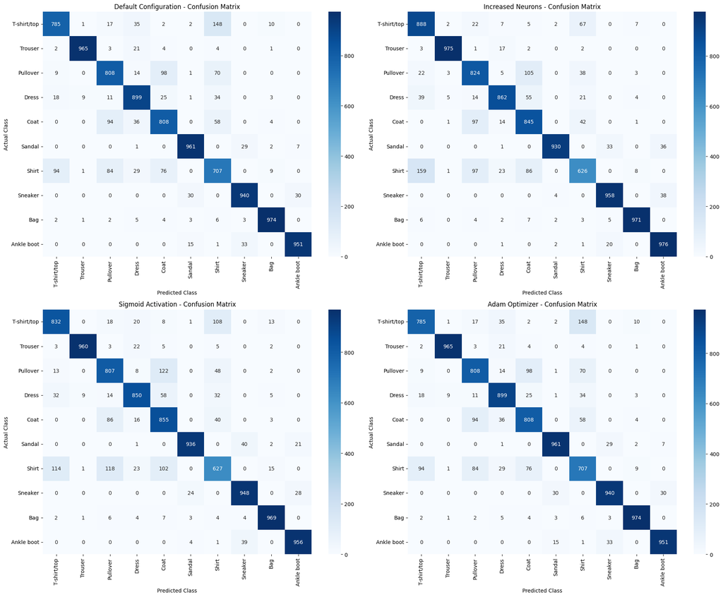

```python
y_test_indices = np.argmax(y_test, axis=1)

predictions = {
    'Default Configuration': np.argmax(model.predict(x_test), axis=1),
    'Increased Neurons': np.argmax(modelNeurons.predict(x_test), axis=1),
    'Sigmoid Activation': np.argmax(modelActivate.predict(x_test), axis=1),
    'Adam Optimizer': np.argmax(modelOptimize.predict(x_test), axis=1)
}

fig, axs = plt.subplots(2, 2, figsize=(20, 16))
axs = axs.flatten()
for i, (title, pred) in enumerate(predictions.items()):
    cm = confusion_matrix(y_test_indices, pred)
    sns.heatmap(cm, annot=True, fmt="d", cmap="Blues", ax=axs[i], xticklabels=class_names, yticklabels=class_names)
    axs[i].set_title(f'{title} - Confusion Matrix')
    axs[i].set_ylabel('Actual Class')
    axs[i].set_xlabel('Predicted Class')

plt.tight_layout()
plt.show()
```

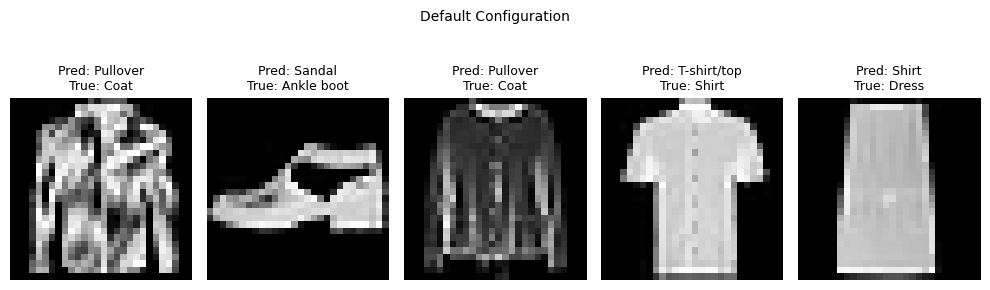

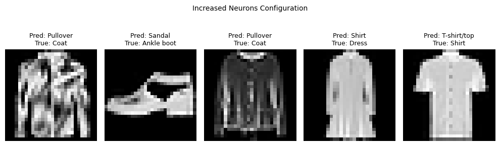

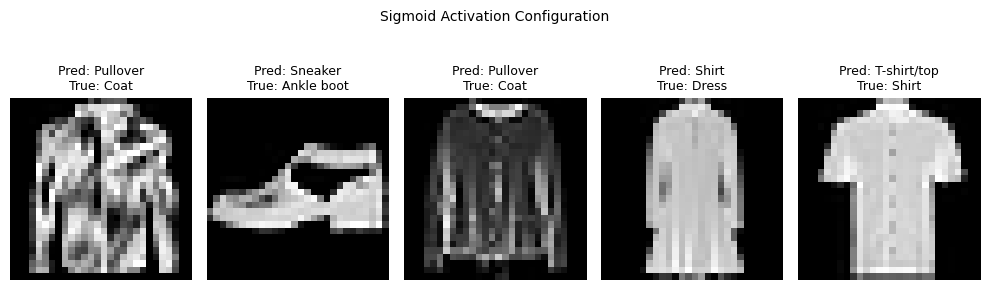

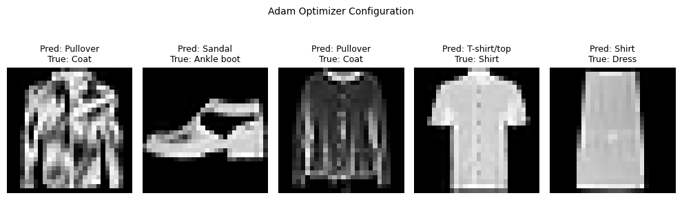

```python
def plot_incorrect_predictions(model, x_test, y_true, class_names, num_images=5, title=""):
    y_pred = model.predict(x_test)
    predicted_classes = np.argmax(y_pred, axis=1)
    true_classes = np.argmax(y_true, axis=1)
    incorrect_indices = np.nonzero(predicted_classes != true_classes)[0]

    plt.figure(figsize=(num_images * 2, 3))
    for i, incorrect in enumerate(incorrect_indices[:num_images]):
        plt.subplot(1, num_images, i + 1)
        plt.imshow(x_test[incorrect].reshape(28, 28), cmap='gray', interpolation='none')
        plt.title(f"Pred: {class_names[predicted_classes[incorrect]]}\nTrue: {class_names[true_classes[incorrect]]}", fontsize=9)
        plt.axis('off')
    plt.suptitle(title, fontsize=10, y=1.05)
    plt.tight_layout()
    plt.show()

plot_incorrect_predictions(model, x_test, y_test, class_names, title="Default Configuration")
plot_incorrect_predictions(modelNeurons, x_test, y_test, class_names, title="Increased Neurons Configuration")
plot_incorrect_predictions(modelActivate, x_test, y_test, class_names, title="Sigmoid Activation Configuration")
plot_incorrect_predictions(modelOptimize, x_test, y_test, class_names, title="Adam Optimizer Configuration")
```

#### Selection of the best configuration:

A good model is not only about high accuracy but also about how consistently it can execute (i.e., with low loss). For this reason, we should take into account both the ultimate accuracy and loss metrics when determining the optimal configuration.